# presentation

September 21, 2021

#### Wrangling

This is the first part of this homework, called wrangling. The data sets are from the Gapminder website (https://www.gapminder.org/data/). Pick two individual indicators and download each of their data sets into .cvs data files. Then, wrangle these two data files into one tibble that is “tidy”.

I choose the adult literacy rate and adult employment rate to find the relationship between this two indicators.

Literacy: Adult literacy rate is the percentage of people ages 15 and above who can, with understanding, read and write a short, simple statement on their everyday life.

Employment: Percentage of total population, age group 15+, that has been employed during the given year.

##### Import datasets

The “literacy” illustrates the literacy rate on different countries on 2000.

```
## [1] 126
```

```
##                country literacy
## 3               Angola     67.4
## 5              Albania     98.7
## 8            Argentina     97.2
## 9              Armenia     99.4
## 10 Antigua and Barbuda     99.0
## 15          Bangladesh     47.5
```

The “employment” illustrates the employment rate on different countries on 2000.

```
## [1] 0
```

```
##                country employment
## 1          Afghanistan       45.9
## 2               Angola       59.3
## 3              Albania       48.0
## 4 United Arab Emirates       73.5
## 5            Argentina       51.0
## 6              Armenia       49.1
```

##### Create tibbles

```
## # A tibble: 30 × 2
##    country             literacy
##    <fct>                  <dbl>
##  1 Angola                  67.4
##  2 Albania                 98.7
##  3 Argentina               97.2
##  4 Armenia                 99.4
##  5 Antigua and Barbuda     99
##  6 Bangladesh              47.5
##  7 Bulgaria                98.2
##  8 Bahrain                 86.5
##  9 Bolivia                 86.7
## 10 Brunei                  92.7
## # … with 20 more rows
```

```
## # A tibble: 189 × 2
##    country              employment
##    <fct>                     <dbl>
##  1 Afghanistan                45.9
##  2 Angola                     59.3
##  3 Albania                    48
##  4 United Arab Emirates       73.5
##  5 Argentina                  51
##  6 Armenia                    49.1
##  7 Australia                  59.3
##  8 Austria                    55.6
##  9 Azerbaijan                 56.4
## 10 Burundi                    81.7
## # … with 179 more rows
```

##### Combine two tibbles

```
##                  country literacy employment
## 1                 Angola    67.40       59.3
## 2                Albania    98.70       48.0
## 3              Argentina    97.20       51.0
## 4                Armenia    99.40       49.1
## 6             Bangladesh    47.50       55.6
## 7               Bulgaria    98.20       41.4
## 8                Bahrain    86.50       65.0
## 9                Bolivia    86.70       67.0
## 10                Brunei    92.70       63.9
## 11      Congo, Dem. Rep.    67.20       69.6
## 12                Cyprus    96.80       59.6
## 13               Ecuador    91.00       60.5
## 14                Greece    96.00       46.9
## 15              Honduras    80.00       61.7
## 16               Croatia    98.20       44.9
## 17                 India    61.00       56.7
## 18                 Italy    98.40       43.4
## 19                   Lao    68.70       78.5
## 20             Sri Lanka    90.70       52.3
## 21             Lithuania    99.70       48.8
## 22          Macao, China    91.30       61.7
## 23               Namibia    85.00       45.2
## 24                 Niger     9.39       77.6
## 25             Nicaragua    76.70       57.9
## 26                 Nepal    48.60       84.0
## 27 Sao Tome and Principe    84.90       47.0
## 28           Timor-Leste    37.60       52.0
## 29               Ukraine    99.40       49.8
## 30             Venezuela    93.00       55.9
```

#### Creating plot

Before we do the visualization, we can guess whether the higher the adult literacy rate is, the higher the adult employment rate will be. Since the majority of jobs require people understanding, read and write a short, simple statement, which is the basic requirement, this guess is reasonable.

Now, Create a ggplot visualization of this data.

##### ggplot

Let’s turn this code into a reusable template for making graphs with ggplot2. ggplot(data = ) + (mapping = aes())

Draw a scatter plot.

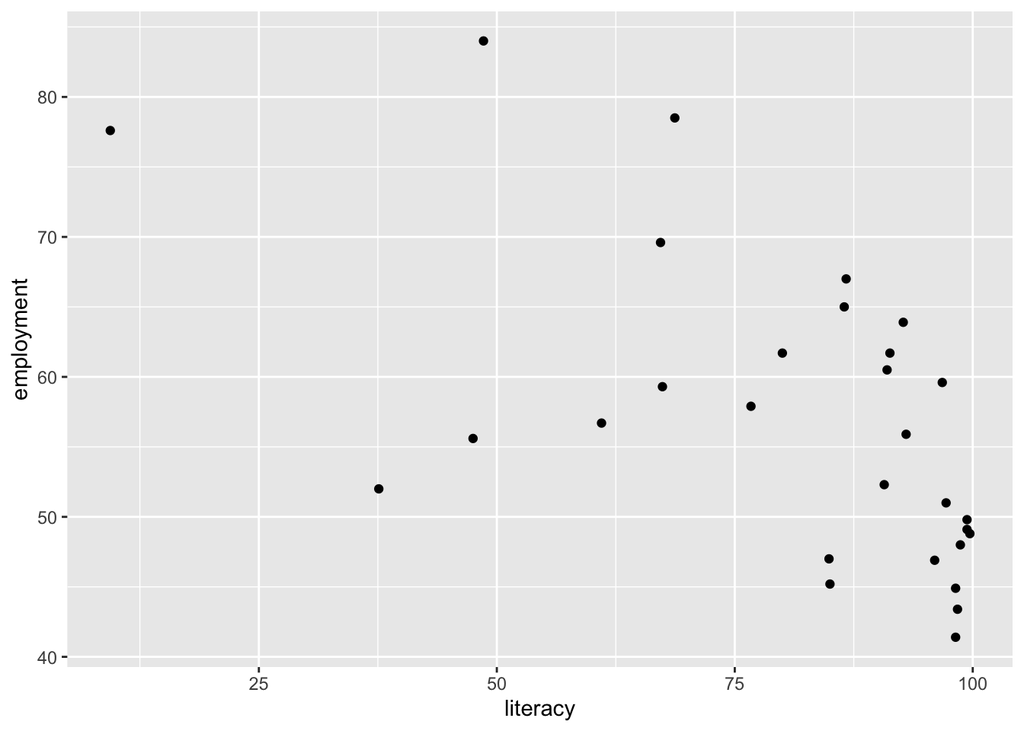

Draw a scatter plot with colors.

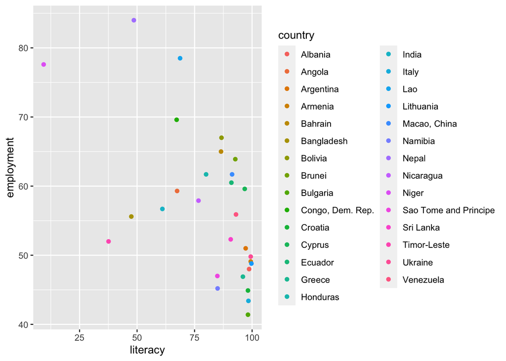

Exploring continuous variales – distributions

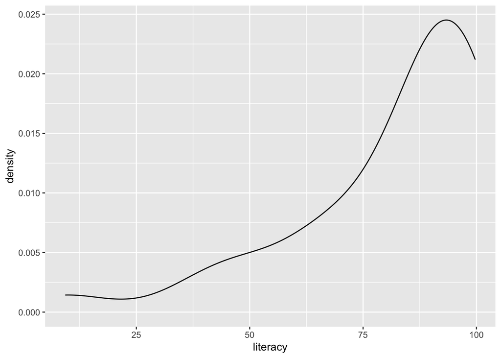

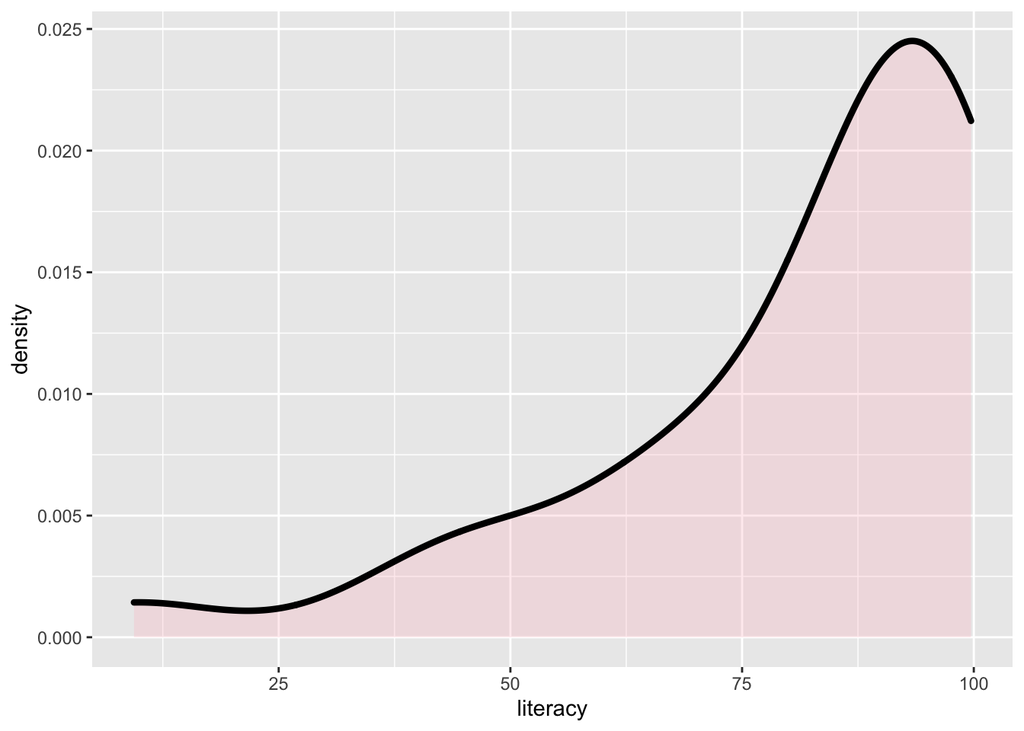

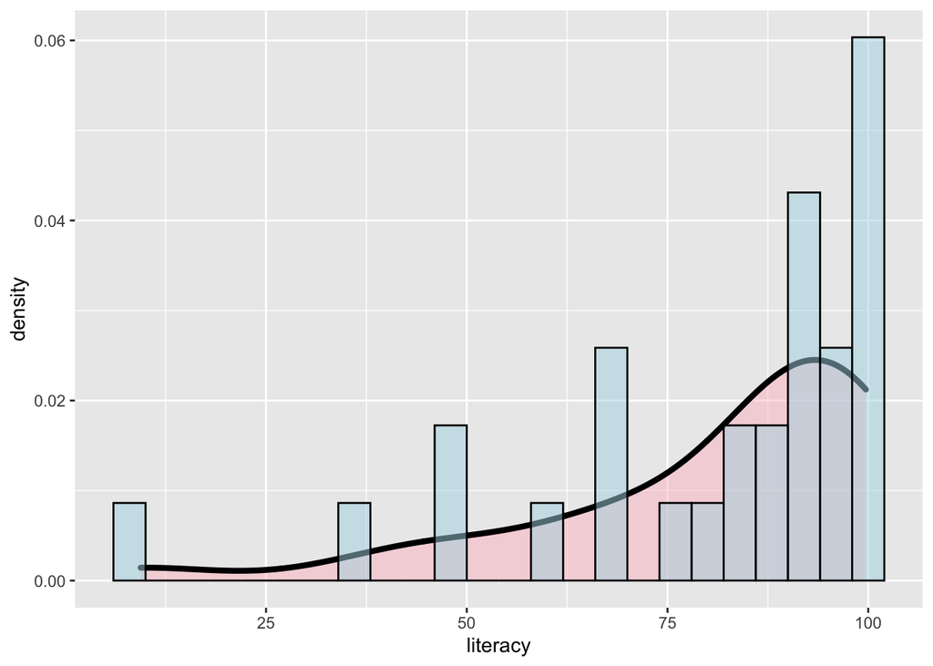

```
## mapping: y = ~..density..
## geom_bar: na.rm = FALSE, orientation = NA
## stat_bin: binwidth = 4, bins = NULL, na.rm = FALSE, orientation = NA, pad = FALSE
## position_stack
```

using layers to draw a plot.

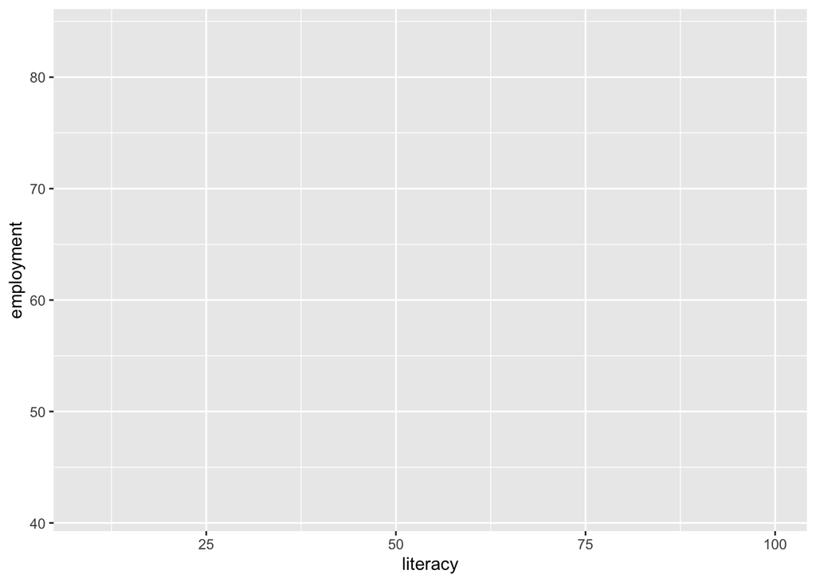

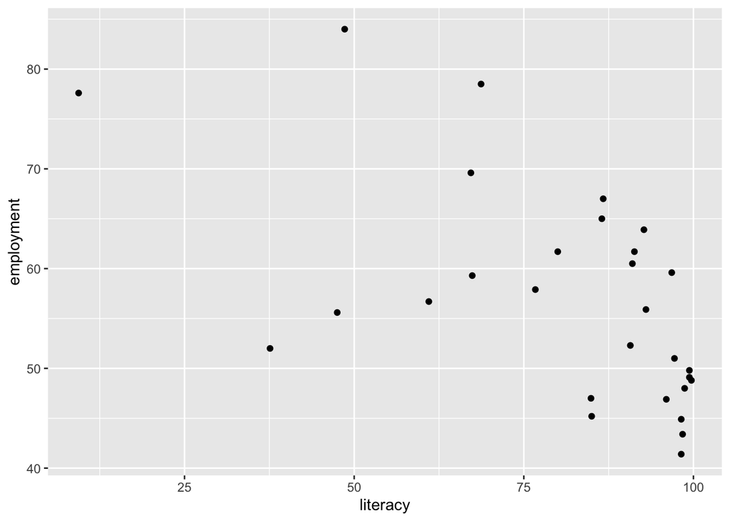

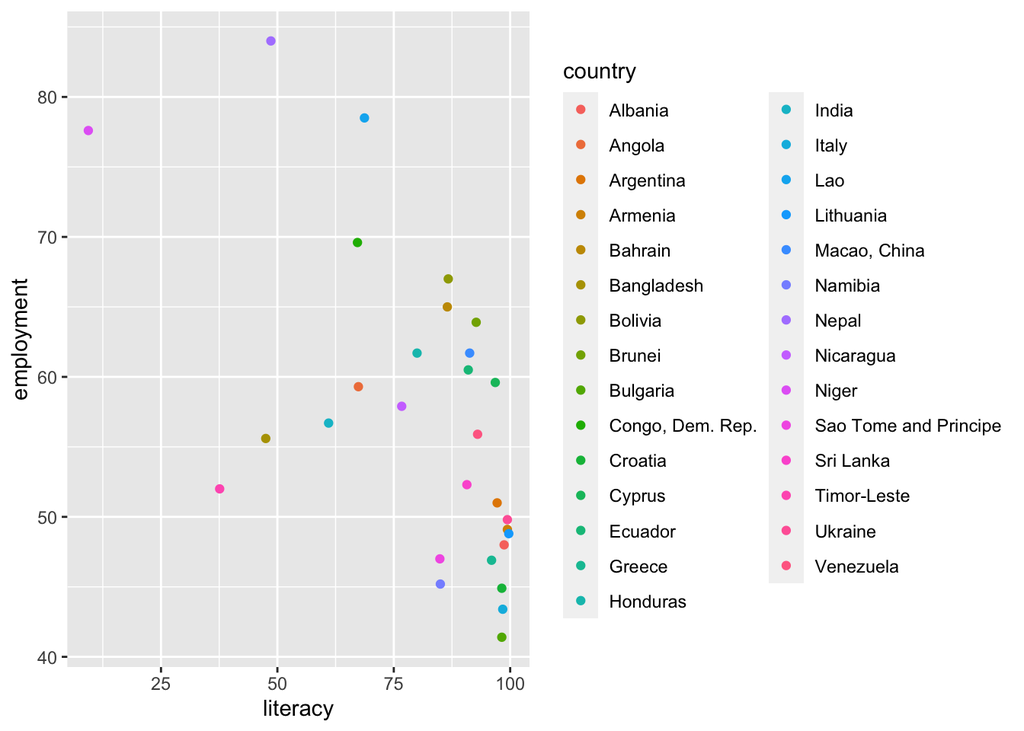

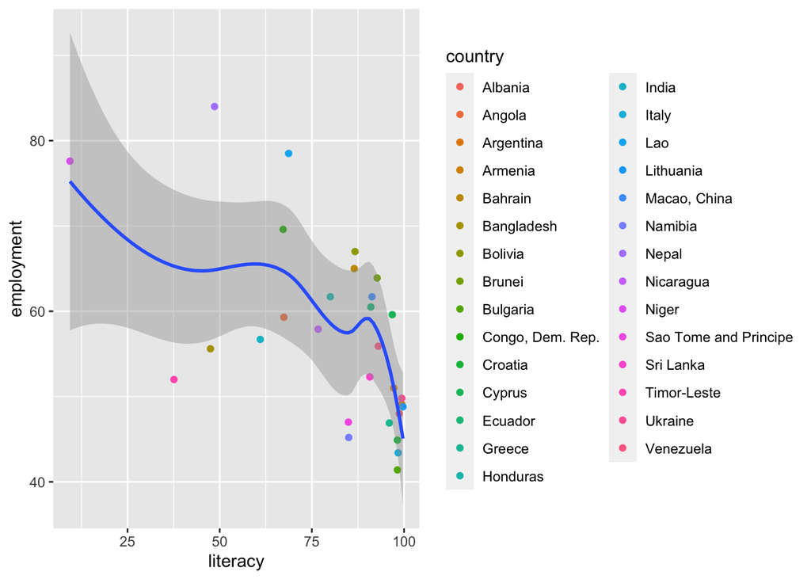

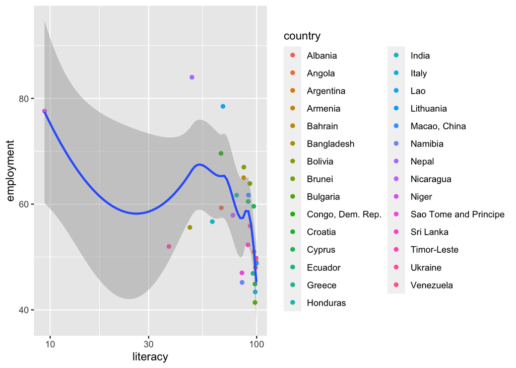

##### World Map

```
## ### Welcome to rworldmap ###
```

```
## For a short introduction type :   vignette('rworldmap')
```

Now, we are going to see the dimension of trend.

```
## [1] 29  3
```

Imput the column name of trend.

```
## [1] "country"    "literacy"   "employment"
```

Make sure that no missing values found.

```
## [1] 29
```

See Hmisc.

```
## trend
##
##  3  Variables      29  Observations
## --------------------------------------------------------------------------------
## country
##        n  missing distinct
##       29        0       29
##
## lowest : Albania               Angola                Argentina             Armenia               Bahrain
## highest: Sao Tome and Principe Sri Lanka             Timor-Leste           Ukraine               Venezuela
## --------------------------------------------------------------------------------
## literacy
##        n  missing distinct     Info     Mean      Gmd      .05      .10
##       29        0       27        1    80.96    22.71    41.56    48.38
##      .25      .50      .75      .90      .95
##    68.70    90.70    97.20    98.84    99.40
##
## lowest :  9.39 37.60 47.50 48.60 61.00, highest: 98.20 98.40 98.70 99.40 99.70
## --------------------------------------------------------------------------------
## employment
##        n  missing distinct     Info     Mean      Gmd      .05      .10
##       29        0       28        1    57.04    12.27    44.00    45.14
##      .25      .50      .75      .90      .95
##    48.80    55.90    61.70    71.20    78.14
##
## lowest : 41.4 43.4 44.9 45.2 46.9, highest: 67.0 69.6 77.6 78.5 84.0
## --------------------------------------------------------------------------------
```

```
## 29 codes from your data successfully matched countries in the map
## 0 codes from your data failed to match with a country code in the map
##      failedCodes failedCountries
## 214 codes from the map weren't represented in your data
```

Finally, we build the “literacy rate” map over the 29 countries.

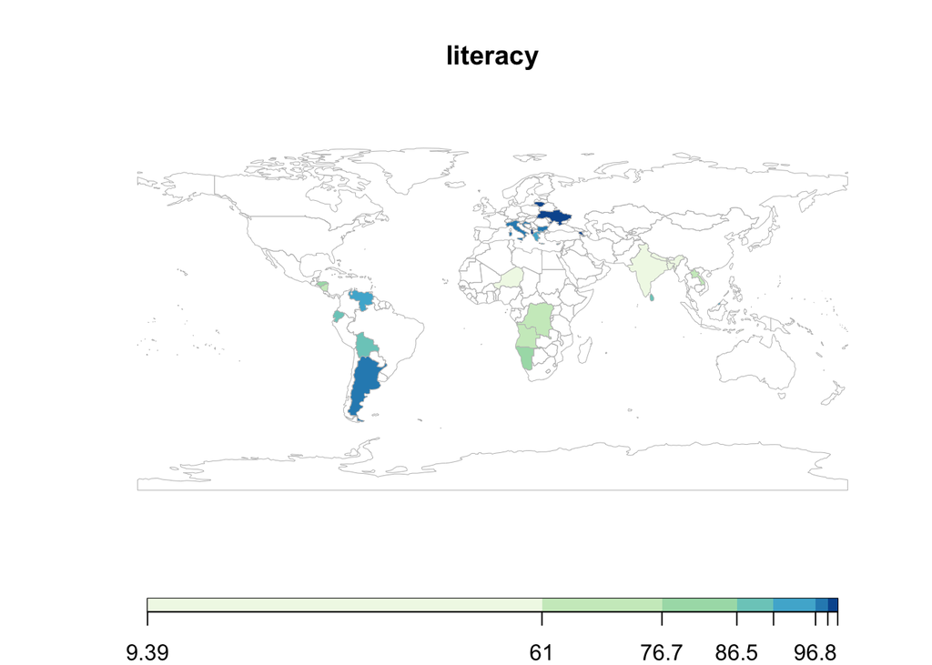

Finally, we build the “employment rate” map over the 29 countries.

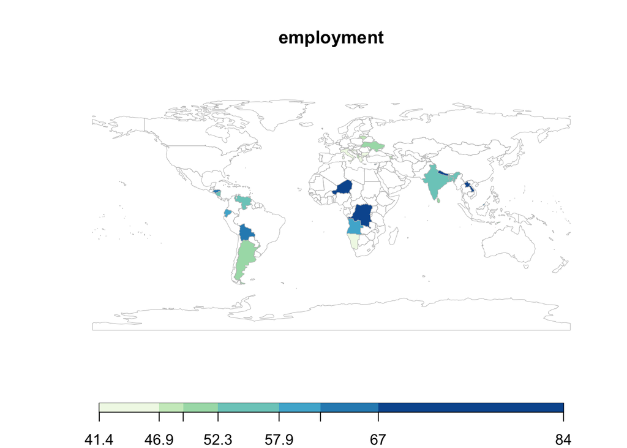